# Notes L

Exploratory Data Analysis & Simple Linear Regression

```r
#LOAD PACKAGES
library(tidyverse)
library(infer)
library(broom)
set.seed(999)
```

Let’s this about some ways we can summarize and explore relationships between two variables:

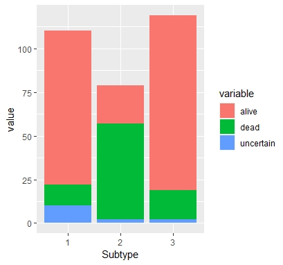

(a) Two Categorical

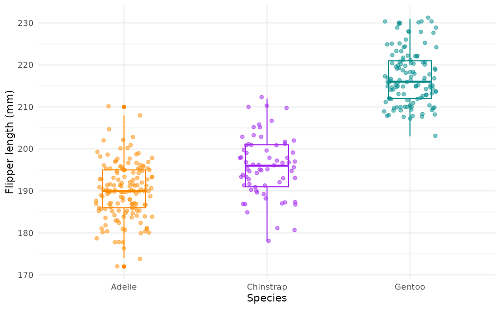

(b) One Numeric, One Categorical

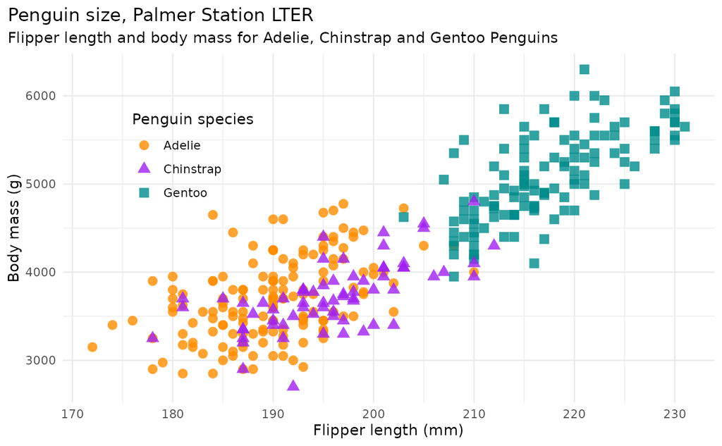

(c) Two Numeric Variables

Figure 1: Types of Plots with Two Variables

Today, we are going to dive into the “two numeric variables” case.

# Motivation using data we have seen before

## Sustainability Data

```r
#LOAD DATA
power <- read.csv("../data/power.csv")
```

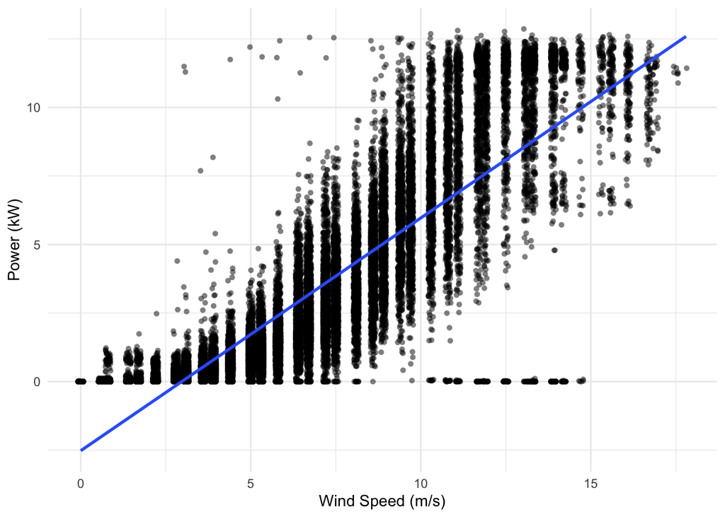

```r
 power %>%
   drop_na() %>%
   ggplot(aes(x=windSpeedRadarTower_m_per_sec, y=power_kW)) +
   geom_point(pch=16, alpha=0.5, position="jitter") +
   geom_smooth(method=lm, se=FALSE) +
   labs(x = "Wind Speed (m/s)", y = "Power (kW)") +
   theme_minimal()
```

## Banner-tailed Kangaroo Rats in Portal, AZ

```r
#load kangaroo rat data
kangaroo_rats <- read.csv("https://github.com/weecology/PortalData/raw/main/Rodents/Portal_rodent.csv") %>%
  filter(species %in% c("DS")) %>%
  select(year, month, day, species, sex, hfl, wgt)
```

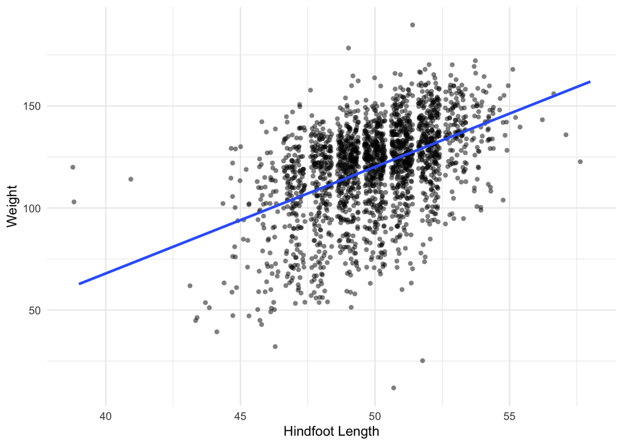

```r
kangaroo_rats %>%
   drop_na() %>%
   ggplot(aes(x=hfl, y=wgt)) +
   geom_point(pch=16, alpha=0.5, position="jitter") +
   geom_smooth(method=lm, se=FALSE) +
   labs(x = "Hindfoot Length", y = "Weight") +
   theme_minimal()
```

# Correlation

Correlation always takes on values between -1 and 1, describes the strength of the linear relationship between two variables.

[figure not shown]

```r
kangaroo_rats <- kangaroo_rats %>%
  drop_na(hfl) %>%
  drop_na(wgt)

#cor(x, y)
cor(kangaroo_rats$hfl, kangaroo_rats$wgt)
```

```
[1] 0.4741858
```

# Correlation Does Not Imply Causation

[figure not shown]

[figure not shown]

[figure not shown]

# Equations and Interpretation of Coefficients

Want to fit a linear model:

$$\hat{y} = b_0 + b_1x$$

To fit a linear regression model we need the `lm()` function.

```r
#modelname <- lm(y ~ x, data = dataset)

power_model <- lm(power_kW ~ windSpeedRadarTower_m_per_sec,data=power)

# calling the name of the model spits out the coefficients (slope and y-intercept)
power_model
```

```
Call:
lm(formula = power_kW ~ windSpeedRadarTower_m_per_sec, data = power)

Coefficients:
                  (Intercept)  windSpeedRadarTower_m_per_sec
                      -2.5469                         0.8558
```

To interpret the y-intercept coefficient ($b_0$):

- If the wind speed is 0, this model predicts that the power generated will be -2.5 kW on average.

To interpret the slope coefficient ($b_1$):

- For every additional m per sec of wind speed, this model predicts that the power generated will increase by 0.8558 kW.